# Lab 02: Part 2: Filtering and Transformation in phyloseq

Paul J. McMurdie

July 21, 2014

# Outline of Lab 02, Part 2

Expected Time to Completion: 45 minutes

- Remaining Accessor examples
- Merging (DB *join*)
- Independent Filtering
- Basic Transformations (proportion, log)

# Startup R session

# Load phyloseq

Use gridExtra and ggplot2 packages for side-by-side plots in some places (`arrangeGrob`). Check your own installed package versions and note any differences. If you’re behind, consider installing an update with `install.packages`.

```r
library("phyloseq"); packageVersion("phyloseq")
```

```
## [1] '1.9.11'
```

```r
library("gridExtra"); packageVersion("gridExtra")
```

```
## [1] '0.9.1'
```

```r
library("ggplot2"); packageVersion("ggplot2")
```

```
## [1] '1.0.0'
```

# Load data from previous lab

```r
load("example-data.RData")
ls()
```

```
## [1] "closedps"  "metadata"  "ps0"       "qiimedata"
```

# Accessors

# Accessors

We have shown some already, but phyloseq provides special accessor functions, which I sometimes call *accessors*, that return specific information about a phyloseq data object, if that data is available. Most accessors will return `NULL` or stop with an error if the requested data is absent. Accessors are useful for both package development (separating data structure from function code) and for direct interaction by users.

# Accessors

```r
ntaxa(closedps)
```

```
## [1] 73
```

```r
nsamples(closedps)
```

```
## [1] 9
```

```r
sample_names(closedps)[1:5]
```

```
## [1] "PC.354" "PC.355" "PC.356" "PC.481" "PC.593"
```

```r
taxa_names(closedps)[1:5]
```

```
## [1] "169901"  "673925"  "4470518" "1107945" "4346374"
```

# Accessors

```r
rank_names(closedps)
```

```
## [1] "Kingdom" "Phylum"  "Class"   "Order"   "Family"  "Genus"   "Species"
```

```r
sample_variables(closedps)
```

```
## [1] "X.SampleID"           "BarcodeSequence"      "LinkerPrimerSequence"
## [4] "Treatment"            "DOB"                  "Description"
```

# Accessors

```r
otu_table(closedps)[1:5, 1:5]
```

```
## OTU Table:          [5 taxa and 5 samples]
##                      taxa are columns
##
##          169901 673925 4470518 1107945 4346374
##   PC.354      0      0       2       0       0
##   PC.355      0      0      16       0       0
##   PC.356      0      0       0       0       0
##   PC.481      0      0       1       1       0
##   PC.593      0      5       0       0       0
```

# Accessors

```r
sample_data(closedps)[1:5, 1:5]
```

```
## Sample Data:        [5 samples by 5 sample variables]:
##        X.SampleID BarcodeSequence  LinkerPrimerSequence Treatment      DOB
## PC.354     PC.354    AGCACGAGCCTA YATGCTGCCTCCCGTAGGAGT   Control 20061218
## PC.355     PC.355    AACTCGTCGATG YATGCTGCCTCCCGTAGGAGT   Control 20061218
## PC.356     PC.356    ACAGACCACTCA YATGCTGCCTCCCGTAGGAGT   Control 20061126
## PC.481     PC.481    ACCAGCGACTAG YATGCTGCCTCCCGTAGGAGT   Control 20070314
## PC.593     PC.593    AGCAGCACTTGT YATGCTGCCTCCCGTAGGAGT   Control 20071210
```

# Accessors

```r
tax_table(closedps)[1:5, 1:4]
```

```
## Taxonomy Table:     [5 taxa by 4 taxonomic ranks]:
##         Kingdom    Phylum           Class
## 169901  "Bacteria" "TM7"            "TM7-3"
## 673925  "Bacteria" "Proteobacteria" "Epsilonproteobacteria"
## 4470518 "Bacteria" "Bacteroidetes"  "Bacteroidia"
## 1107945 "Bacteria" "Bacteroidetes"  "Bacteroidia"
## 4346374 "Bacteria" "Bacteroidetes"  "Bacteroidia"
##         Order
## 169901  "CW040"
## 673925  "Campylobacterales"
## 4470518 "Bacteroidales"
## 1107945 "Bacteroidales"
## 4346374 "Bacteroidales"
```

# Accessors

```r
phy_tree(closedps)
```

```
##
## Phylogenetic tree with 73 tips and 72 internal nodes.
##
## Tip labels:
##  169901, 673925, 4470518, 1107945, 4346374, 4414420, ...
## Node labels:
##  , , , , , , ...
##
## Rooted; includes branch lengths.
```

# Accessors - Questions?

Did I miss any that you’re curious about? Any “slices” of data that you’re wondering about how to get at?

# Independent Filtering

# Motivation

For details see the [Independent Filtering vignette](http://bioconductor.org/packages/release/bioc/vignettes/genefilter/inst/doc/independent_filtering.pdf) of the [genefilter package](http://bioconductor.org/packages/release/bioc/html/genefilter.html).

The idea of independent ﬁltering is to ﬁlter out those tests from the procedure that have no (or little) chance of showing signiﬁcant evidence, **without even looking at their test statistic**.

No Cheating! :-)

# Motivation

More rigorously, a good choice for a filtering criterion is one that:

- is statistically independent from the test statistic under the null hypothesis
- is correlated with the test statistic under the alternative, and
- does not notably change the dependence structure – if there is any – between the tests that pass the filter, compared to the dependence structure between the tests before filtering.

Typically, this results in increased detection power at the same experiment-wide type I error, as measured in terms of the false discovery rate (FDR).

(FDR and multiple testing will be discussed later)

# Motivation

This notion of suprious or “noisy” OTUs is an issue in metagenome data that extends beyond multiple testing, but I find this a good motivation for why we might want to filter OTUs from the data.

We will handle these details more rigorously later.

**In this lab we are interested in demonstrating the mechanics of filtering** OTUs in phyloseq, so that you’ll know how to perform filtering when we later discuss *multiple testing*.

# Independent Filtering - tools

Filtering in phyloseq is designed in a modular fashion.This includes:

- `prune_taxa` - simple “keep only these OTUs” filtering
- `prune_samples` - simple “keep only these samples” filtering
- `filterfun_sample` - define arbitrary filter function
- `genefilter_sample` - apply filtering function (within sample)
- `filter_taxa` function for taxa-wise (across sample) filtering

# Independent Filtering - examples

```r
cpsf = filter_taxa(closedps, function(x) mean(x) > 1, TRUE)
```

# Independent Filtering - examples

Exercise: Construct your own, more complicated filter, that requires that OTUs be present above some proportion threshold in at least 2 samples.

# Merging Data

# Merging Data - Motivation

Merging OTU or sample indices based on variables in the data can be a useful means of reducing noise or excess features, or for some other reason that oyu know ahead of time, or want to explore.

Some examples might be to merge the samples in a dataset that are from the same environment, or to merge OTUs that are from the same taxonomic genera.

# Merging Data - joins, etc.

General database **join** operations:

- Merge two data frames by common columns or row names
- etc.

```r
base::merge
```

# Merging Data - joins, etc.

Other useful data “munging” packages in R

- [data.table](http://cran.r-project.org/web/packages/data.table/index.html)
- [dplyr](http://cran.r-project.org/web/packages/dplyr/index.html)
- [plyr](http://cran.r-project.org/web/packages/plyr/index.html)
- [reshape2](http://cran.r-project.org/web/packages/reshape2/index.html)
- *others*

# Merging Data

phyloseq includes support for two completely different categories of **merging**.

- `merge_samples`
- `merge_taxa`
- `tax_glom`
- `tip_glom`

See the [merge tutorial](http://joey711.github.io/phyloseq/merge)

# Merging - `merge_samples`

`merge_samples` can be very useful if you’d like to see what happens to an analysis if you remove the indivual effects between replicates or between samples from a particular explanatory variable. With the `merge_samples` function, the abundance values of merged samples are summed and effects related to individual samples are obsecured. Some [filtering steps](http://joey711.github.com/phyloseq/preprocess) you may want to do first.

# Merging - `merge_samples`

Beware that non-target variables can get mangled!

```r
mcps = merge_samples(closedps, "Treatment")
sample_data(mcps)
```

```
## Sample Data:        [2 samples by 6 sample variables]:
##         X.SampleID BarcodeSequence LinkerPrimerSequence Treatment      DOB
## Control        3.0            5.20                    1         1 20065017
## Fast           7.5            4.75                    1         2 20077865
##         Description
## Control         3.0
## Fast            7.5
```

```r
sample_names(mcps)
```

```
## [1] "Control" "Fast"
```

# Merging - `merge_samples`

As emphasized earlier, the OTU abundances of merged samples are summed. Let’s inspect

```r
otu_table(mcps)[, 1:5]
```

```
## OTU Table:          [5 taxa and 2 samples]
##                      taxa are columns
##         169901 673925 4470518 1107945 4346374
## Control      0      5      19       1       0
## Fast         2      2      26      22      13
```

# Merging Data - `merge_taxa`

Merge a subset of the OTUs in x into a single OTU. Takes a phyloseq object, a vector of OTU IDs that are “equivalent” (should be merged), and returns a new phyloseq object with those merges.

This is “fine-grained” merging, used by `tip_glom` and `tax_glom` (next). Useful if you have a few specific manual OTU merges you need to do.

```r
?merge_taxa
```

# Merging Data - `tax_glom`

The analog to `merge_samples` is, perhaps confusingly, `tax_glom`. However, `tax_glom` is the discrete analog of `tip_glom`, in case you were wondering where the nomenclature went “off the rails”. The `tax_glom` function agglomerates OTUs that are equivalent at a specified taxonomic rank.

# Merging Data - `tax_glom`

```r
get_taxa_unique(closedps, "Phylum")
```

```
## [1] "TM7"             "Proteobacteria"  "Bacteroidetes"   "Deferribacteres"
## [5] "Firmicutes"
```

```r
taxg = tax_glom(closedps, "Phylum")
taxg
```

```
## phyloseq-class experiment-level object
## otu_table()   OTU Table:         [ 5 taxa and 9 samples ]
## sample_data() Sample Data:       [ 9 samples by 6 sample variables ]
## tax_table()   Taxonomy Table:    [ 5 taxa by 7 taxonomic ranks ]
## phy_tree()    Phylogenetic Tree: [ 5 tips and 4 internal nodes ]
```

What just happened? What is `taxg`? What might you use to figure this out?

# Merging Data - `tax_glom`

```r
otu_table(taxg)
```

```
## OTU Table:          [5 taxa and 9 samples]
##                      taxa are columns
##
##          169901 673925 4470518 4374042 259357
##   PC.354      0      0       9       0     90
##   PC.355      0      0      31       0     59
##   PC.356      0      0      23       0     58
##   PC.481      0      0      17       0     72
##   PC.593      0      5      52       0     62
##   PC.607      0      2      38       3     46
##   PC.634      2      0      64       5     14
##   PC.635      0      0      40       2     21
##   PC.636      0      0      46       6     16
```

# Merging Data - `tax_glom`

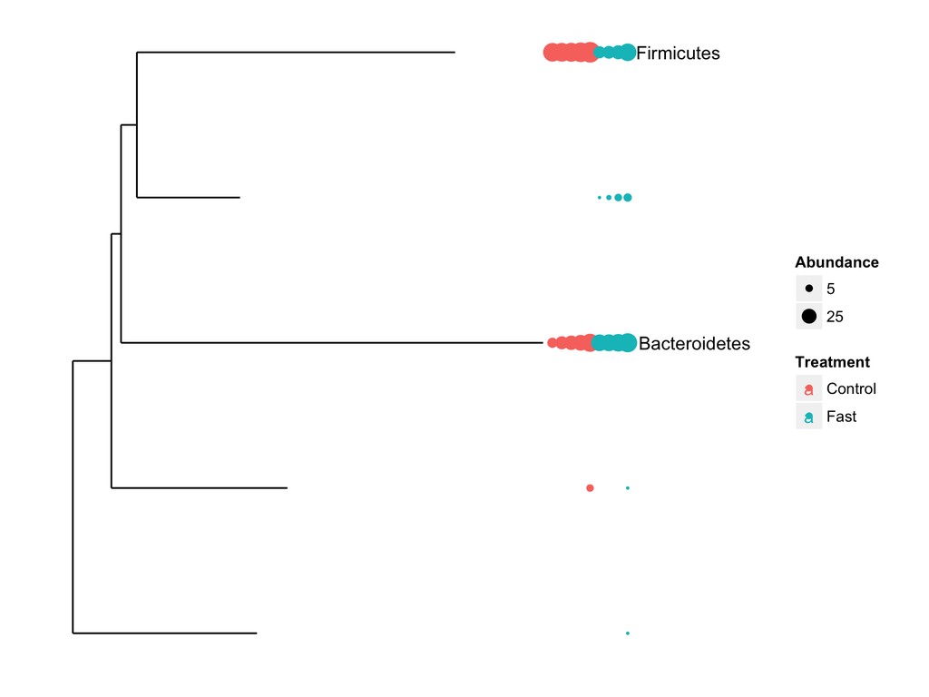

```r
plot_tree(taxg, color = "Treatment", size = "abundance",
          justify = "left", label.tips = "Phylum")
```

# Merging Data - `tax_glom`

- Where are the low-abundance OTUs coming from?
- Any guesses?
- How might you investigate this?

# Merging Data - `tip_glom`

As mentioned earlier, `tip_glom` is the continuous analog of `tax_glom`. Unlike `tax_glom`, though, there are no classification values that might go missing, so the agglomeration is much smoother with not really any potential for “straggling” artifacts, since every branch-length in the tree is available. If you have a tree available, this is recommended over `tax_glom`.

# Merging Data - `tip_glom`

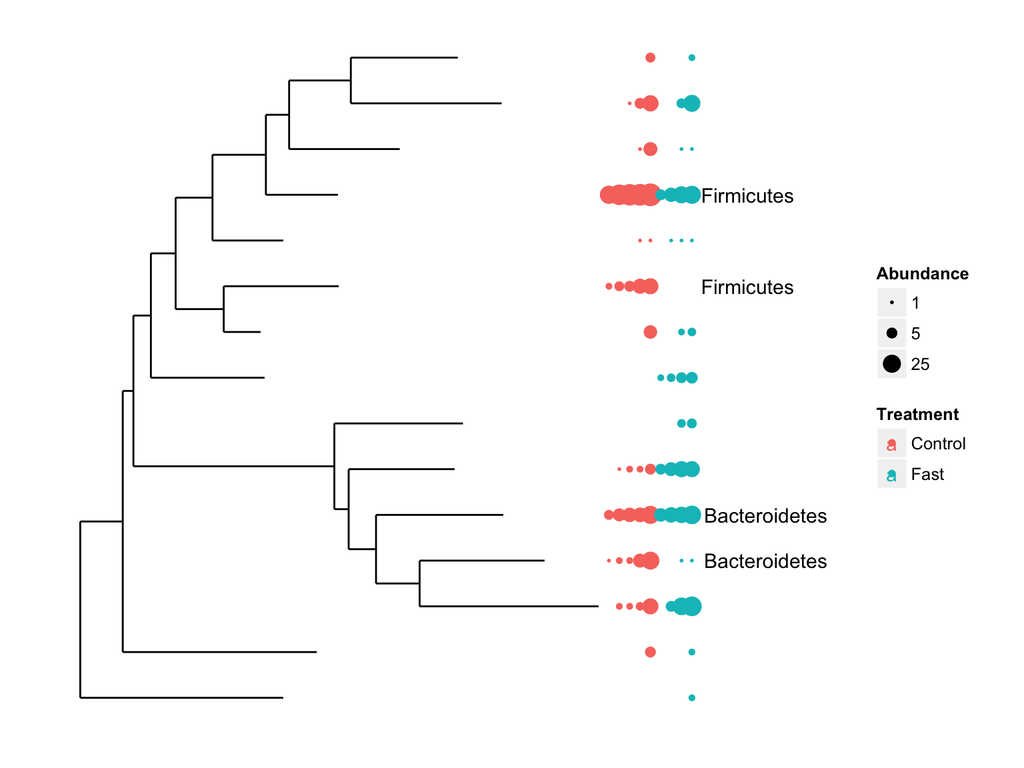

```r
tipg = tip_glom(closedps, 0.4)
plot_tree(tipg, color = "Treatment", size = "abundance",
          justify = "left", label.tips = "Phylum")
```

# Merging Data - `tip_glom`

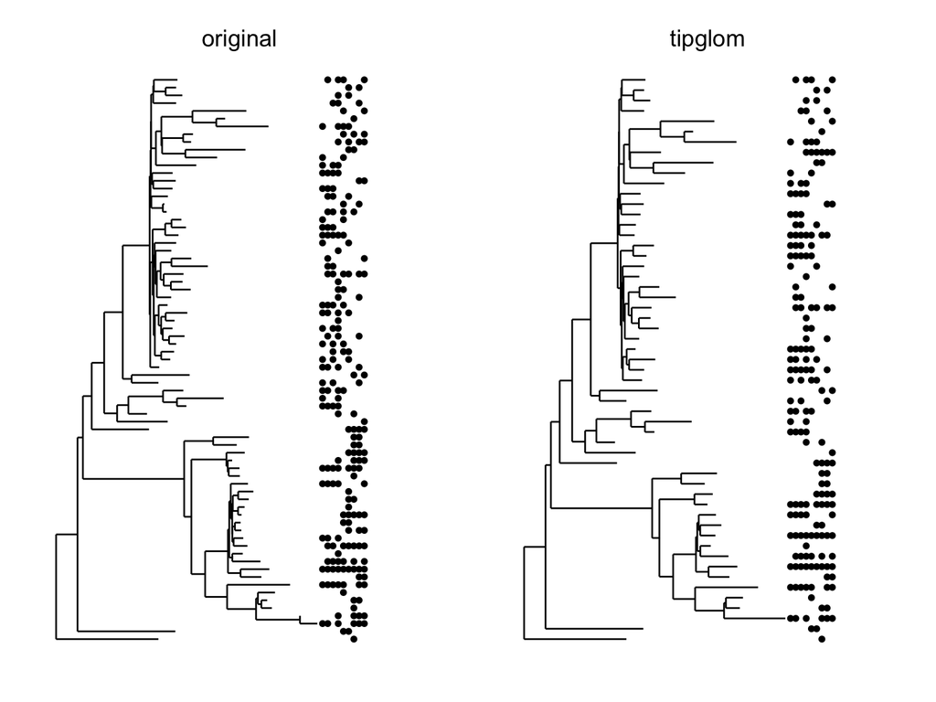

```r
grid.arrange(nrow=1,
  plot_tree(closedps, justify = "left", title = "original"),
  plot_tree(tip_glom(closedps, 0.1), justify = "left", title = "tipglom")
)
```

# Basic Transformations

# Basic Transformations - Motivation

For some applications, it is useful to work with transformed versions of the count data. We will get into the details of more sophisticated transformations later.

- *proportion* (counts of species `i` divided by library size)
- *log*

The [DESeq2 vignette](http://www.bioconductor.org/packages/release/bioc/vignettes/DESeq2/inst/doc/DESeq2.pdf) has a discussion of transformations, and we will use some of the more advanced transformations later on.

# Basic Transformations

For transforming abundance values by an arbitrary R function, phyloseq includes the `transform_sample_counts` function. It takes as arguments a phyloseq-object and an R function, and returns a phyloseq-object in which the abundance values have been transformed, sample-wise, according to the transformations specified by the function.

# Basic Transformations - Proportion

For example, the following command transforms `closedps` abundance counts to fractional abundance (simple proportions).

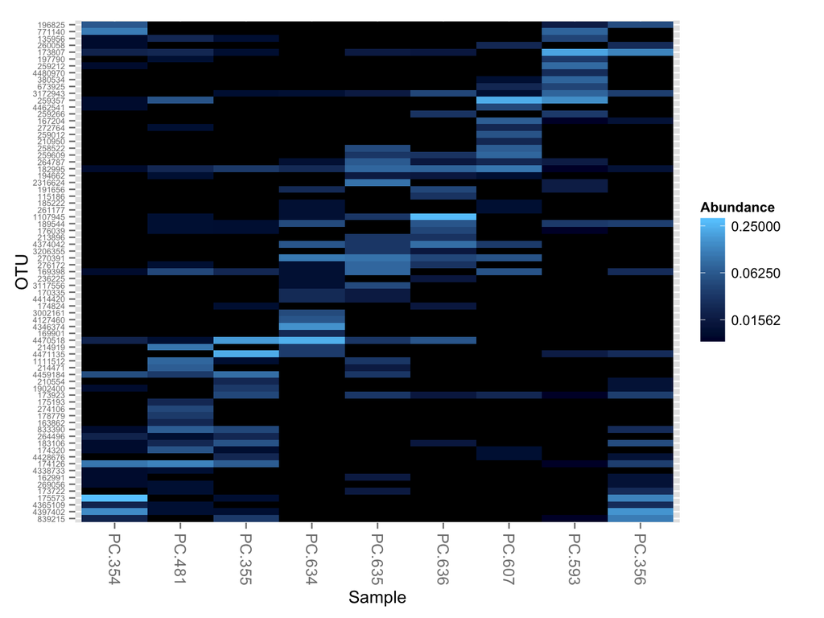

```r
cpsProp = transform_sample_counts(closedps, function(x) x/sum(x) )
plot_heatmap(cpsProp)
```

# Basic Transformations - Logarithm

“Logarithmic Transformation” - Since count values for a gene can be zero in some conditions (and non-zero in others), some advocate the use of pseudocounts:

```r
y = log2(n + 1)
```

or more generally,

```r
y = log2(n + n0)
```

where `n` represents the count values and `n0` is a positive constant.

# Basic Transformations - Logarithm

In phyloseq

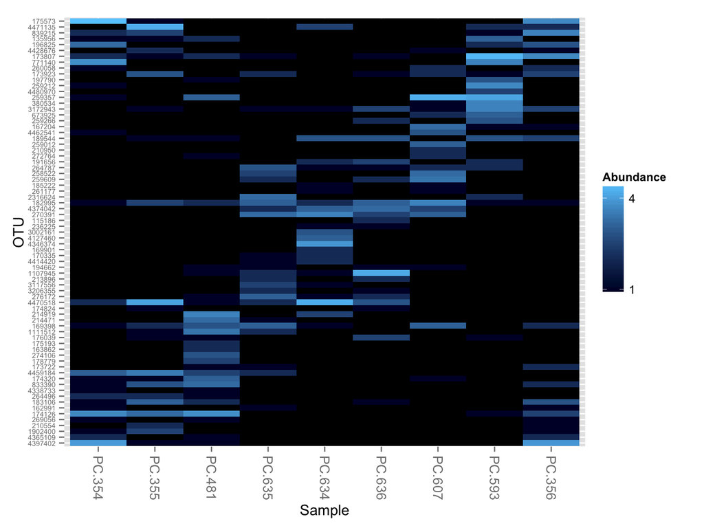

```r
cpsLog = transform_sample_counts(closedps, function(x) log2(x+1L) )
plot_heatmap(cpsLog)
```

# Example Workflow

# Example Workflow

Finally, the following is an example workflow of preprocessing steps that might be applied to a phyloseq dataset prior to further analysis.

# Example Workflow - tip_glom

```r
cpst = tip_glom(closedps, 0.1)
```

# Example Workflow - heuristic filter

Remove OTUs not seen more than 3 times in at least 20% of the samples

```r
cpsf = filter_taxa(cpst, function(x) sum(x > 3) > (0.2 * length(x)), TRUE)
cpsfp = transform_sample_counts(cpsf, function(x) x / sum(x))
```

# Example Workflow - mean prop. filter

```r
keepTaxa = taxa_sums(cpsfp) > 0.01
cpsf <- prune_taxa(keepTaxa, cpsf)
```

# Example Workflow - transform

```r
cpsfProp = transform_sample_counts(cpsf, function(x) x/sum(x))
```

# Example Workflow - taxonomic subset

Subset the data to *Bacteroidetes*, make a plot.

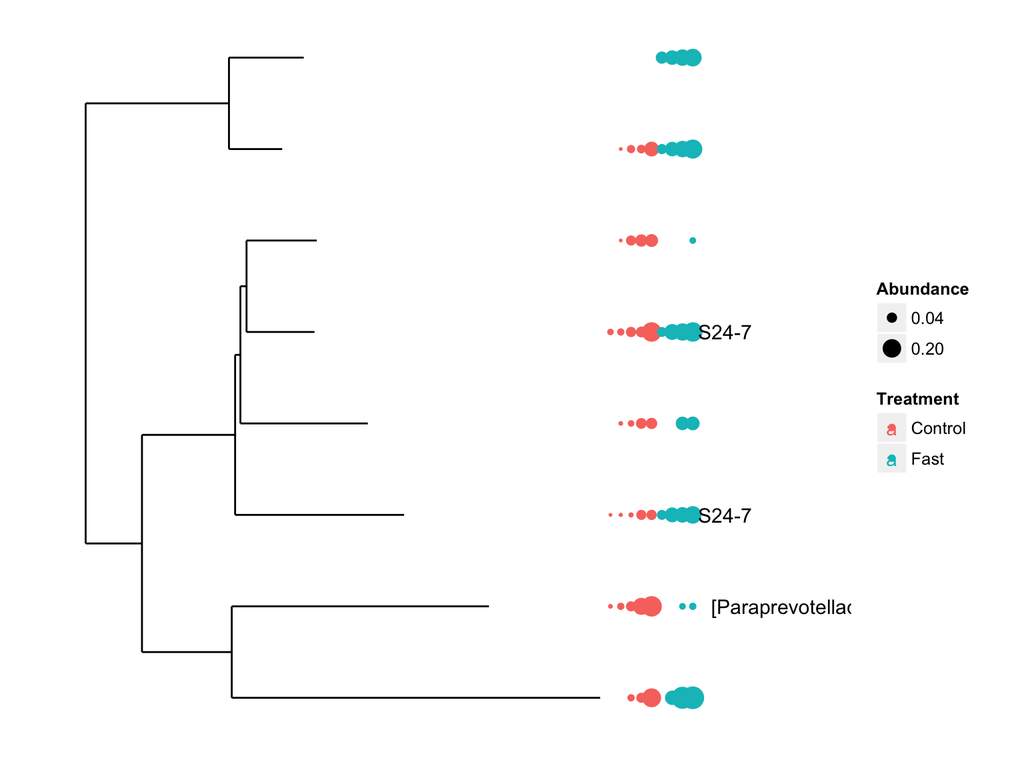

```r
cpsfb = subset_taxa(cpsfProp, Phylum == "Bacteroidetes")
plot_tree(cpsfb, color="Treatment", label.tips = "Family",
          size="abundance", justify = "left")
```

# Lab 02 Exercises

# Exercises

Load a new (to you) dataset e.g.

```r
data("GlobalPatterns")
newData = microbio_me_qiime(1457)
```

- Inspect its contents using **accessors**
- **Filter** OTUs as you see fit (and possibly samples)
- Apply a **transformation**
- **BONUS:** Create a nice plot (not a tree)